# Nimble - Poisson Regression

```r
library(knitr)
library(kableExtra)
library(MASS)                 # Ship data
library(nimble, warn.conflicts = FALSE)
library(coda)                 # MCMC diagnostics
library(mcmcplots)            # MCMC plot
```

## Poisson Regression with offset

- $Y_i|X_i \sim Poisson(\mu_i)$
- $log(\mu_i)=\eta_i=\beta_0+\beta_1x_{1i}+log(t_i)=(\beta_0+log(t_i))++\beta_1x_{1i}$
- $\mu_i=exp(\eta_i)=exp(\beta_0+\beta_1x_{1i}+log(t_i))=exp(\beta_0+\beta_1x_{1i})t_i$

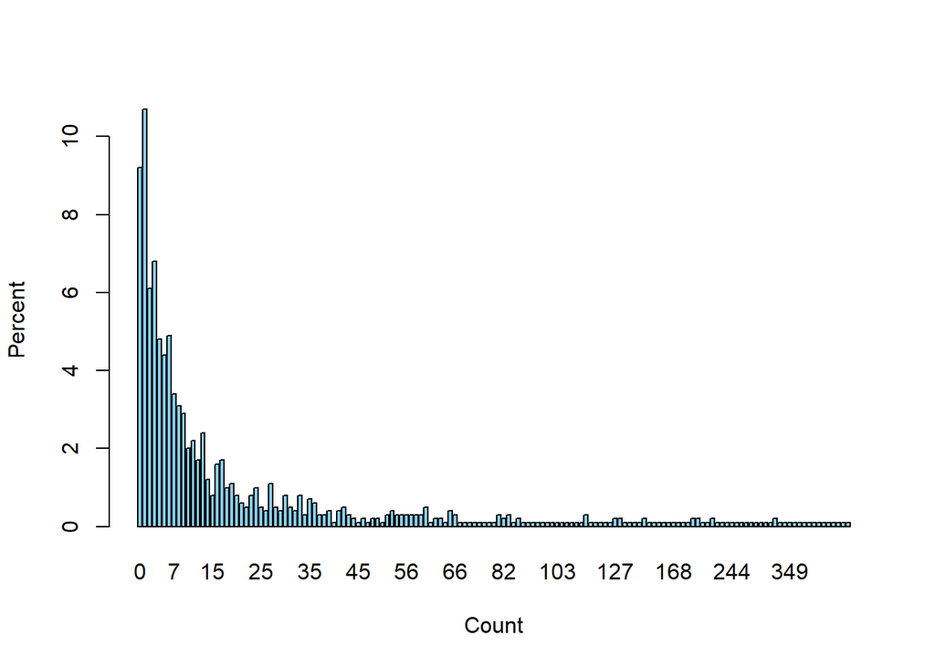

```r
##############
# Simulation #
##############
rm(list = ls())
set.seed(1)
n <- 1000                                   # number of observations
x <- rnorm(n)                               # explanatory variables
X <- cbind(1,x)                             # design matrix
true_betas <- c(0.5,1.5)                    # coefficients

t <- sample(1:10,n,replace=T)               # offset

eta <- X %*% true_betas+log(t)              # plus offset term
mu  <- exp(eta)
y   <- rpois(n,mu)

# histogram
tmp<-table(y)/n*100
barplot(tmp,col="skyblue",ylab="Percent",xlab="Count")
```

Setting

| Parameter | True |
| --- | --- |
| $\beta_0$ | 0.5 |
| $\beta_1$ | 1.5 |

### Frequentist Approach

```r
# Frequentist approach
m <- glm(y~x,family = "poisson",offset=log(t)) # allow intercept
summary(m)
```

```
##
## Call:
## glm(formula = y ~ x, family = "poisson", offset = log(t))
##
## Deviance Residuals:
##     Min       1Q   Median       3Q      Max
## -2.7218  -0.7807  -0.1260   0.6434   3.1393
##
## Coefficients:
##             Estimate Std. Error z value Pr(>|z|)
## (Intercept)  0.50348    0.01066   47.22   <2e-16 ***
## x            1.49991    0.00569  263.61   <2e-16 ***
## ---
## Signif. codes:  0 '***' 0.001 '**' 0.01 '*' 0.05 '.' 0.1 ' ' 1
##
## (Dispersion parameter for poisson family taken to be 1)
##
##     Null deviance: 74770.0  on 999  degrees of freedom
## Residual deviance:  1017.7  on 998  degrees of freedom
## AIC: 4818.4
##
## Number of Fisher Scoring iterations: 4
```

## NIMBLE Procedure

### Step 1: Build Model

- Write the Poisson model:
- $Y_i|X_i \sim Poisson(\mu_i)$
- $log(\mu_i)=\eta_i=\beta_0+\beta_1x_{1i}+log(t_i)$; or
- $\mu_i=exp(\eta_i)=exp(\beta_0+\beta_1x_{1i}+log(t_i))=exp(\beta_0+\beta_1x_{1i})t_i$

```r
#######################
# Model specification #
#######################

# use bugs code in nimbleCode

code <- nimbleCode({
  for(i in 1:n) {
    y[i] ~ dpois(mu[i])
    #mu[i] <- exp(beta0+beta1*x[i]+log(t[i]))
    log(mu[i])<- beta0+beta1*x[i]+log(t[i])
  }
  beta0 ~ dnorm(0, sd = 100)
  beta1 ~ dnorm(0, sd = 100)
})

constants <- list(n = n)
data <- list(y = y,x = x, t=t)              # Need to add offset data
inits <- list(beta0=0, beta1 = 0)
# nimbleModel: check code specification is correct
model <- nimbleModel(code, constants = constants, data = data, inits = inits)
```

```
## defining model...
```

```
## building model...
```

```
## setting data and initial values...
```

```
## running calculate on model (any error reports that follow may simply reflect missing values in model variables) ...
## checking model sizes and dimensions...
## model building finished.
```

### Step 2: Configure Model

- If we want to calculate WAIC, specify **enableWAIC = TRUE** in configuration.
- Default sampler: random walk sampler (scalar adaptive Metropolis-Hastings sampling with a normal proposal distribution)

```r
modelConf <- configureMCMC(model, enableWAIC = TRUE,print = TRUE)
```

```
## ===== Monitors =====
## thin = 1: beta0, beta1
## ===== Samplers =====
## RW sampler (2)
##   - beta0
##   - beta1
```

```r
modelConf$printSamplers()      # Defalut in RW sampler
```

```
## [1] RW sampler: beta0
## [2] RW sampler: beta1
```

### Step 3: Compile Model

- After specifying model, initial values can be changed. Don’t need to run function **nimbleModel()** again.

```r
Cmodel <- compileNimble(model)
```

```
## compiling... this may take a minute. Use 'showCompilerOutput = TRUE' to see C++ compilation details.
```

```
## compilation finished.
```

### Step 4: Build MCMC

```r
modelMCMC <- buildMCMC(modelConf)
```

```
## Monitored nodes are valid for WAIC.
```

```r
modelMCMC <- compileNimble(modelMCMC, project = model)
```

```
## compiling... this may take a minute. Use 'showCompilerOutput = TRUE' to see C++ compilation details.
```

```
## compilation finished.
```

### Step 5: Run MCMC

```r
niter <- 1500
burn  <- 500
set.seed(1)
samples <- runMCMC(modelMCMC, niter = niter,nburnin = burn, nchains = 1,
                   summary = TRUE, WAIC = TRUE)
```

```
## running chain 1...
```

```
## |-------------|-------------|-------------|-------------|
## |-------------------------------------------------------|
```

```r
mcmc.out <- samples$samples
head(mcmc.out)
```

```
##          beta0    beta1
## [1,] 0.5320629 1.484038
## [2,] 0.5320629 1.484038
## [3,] 0.5320629 1.484038
## [4,] 0.5320629 1.484038
## [5,] 0.5320629 1.484038
## [6,] 0.5320629 1.484038
```

```r
out<-samples$summary
kable(out,digits = 4, format = "html") %>% kable_styling(full_width = F)
```

|  | Mean | Median | St.Dev. | 95%CI_low | 95%CI_upp |
| --- | --- | --- | --- | --- | --- |
| beta0 | 0.5022 | 0.5012 | 0.0115 | 0.4823 | 0.5274 |
| beta1 | 1.5008 | 1.5014 | 0.0063 | 1.4859 | 1.5128 |

```r
mcmc.out <- samples$samples
target <- c("beta0","beta1")
mbeta <- colMeans(mcmc.out)[target]
qbeta <- apply(mcmc.out,2,quantile,c(0.025,0.975))[,target]
```

|  | True | MCMC Estimate | Lower CI | Upper CI |
| --- | --- | --- | --- | --- |
| $\beta_{0}$ | 0.5 | 0.5022 | 0.4823 | 0.5274 |
| $\beta_{1}$ | 1.5 | 1.5008 | 1.4859 | 1.5128 |

- Show WAIC

```r
# Show WAIC
samples$WAIC
```

```
## [1] 4818.825
```

- Plot trace plot

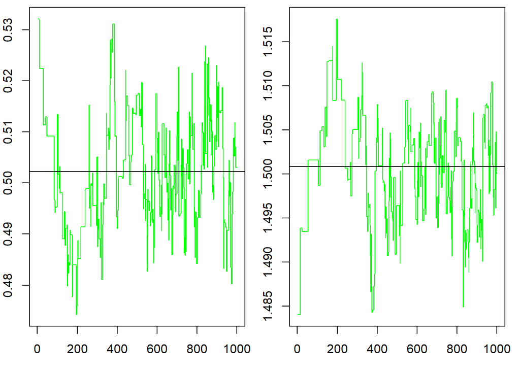

```r
par(mfrow = c(1, 2), mai = c(.6, .4, .1, .2))
plot(mcmc.out[ , "beta0"], type = "l", xlab = "iteration",
     ylab = expression(beta[1]),col="green")
abline(h=mean(mcmc.out[ , "beta0"]))
plot(mcmc.out[ , "beta1"], type = "l", xlab = "iteration",
     ylab = expression(beta[2]),col="green")
abline(h=mean(mcmc.out[ , "beta1"]))
```

- Plot MCMC information (traceplot, density plot,…rtc) from MCMC package.

```r
mcmcplot(mcmc.out,filename = "output-Poi")
```

# Case Study

- Ship data from MASS package
- Outcome ($Y$): Number of damage incidence.
- Variables ($X$): Type (A-E), year of construction (60-64, 65-69, 70-74, 75-79).
- Offset variable: aggregate months of service. The longer ship service, the higher incidence happens.

```r
data(ships)
ships$yearbuilt <- as.factor(ships$year)
fit_ships_poisson <- glm(incidents ~ type + yearbuilt,
                         offset = log(service), family = poisson,
                         data = ships, subset = (service != 0))
summary(fit_ships_poisson)
```

```
##
## Call:
## glm(formula = incidents ~ type + yearbuilt, family = poisson,
##     data = ships, subset = (service != 0), offset = log(service))
##
## Deviance Residuals:
##     Min       1Q   Median       3Q      Max
## -1.9538  -1.0525  -0.4846   0.5779   2.4183
##
## Coefficients:
##             Estimate Std. Error z value Pr(>|z|)
## (Intercept) -6.26892    0.21241 -29.513  < 2e-16 ***
## typeB       -0.55861    0.17767  -3.144  0.00167 **
## typeC       -0.68388    0.32908  -2.078  0.03769 *
## typeD       -0.07032    0.29071  -0.242  0.80887
## typeE        0.30425    0.23581   1.290  0.19698
## yearbuilt65  0.75347    0.14855   5.072 3.94e-07 ***
## yearbuilt70  0.96530    0.16369   5.897 3.70e-09 ***
## yearbuilt75  0.70828    0.22153   3.197  0.00139 **
## ---
## Signif. codes:  0 '***' 0.001 '**' 0.01 '*' 0.05 '.' 0.1 ' ' 1
##
## (Dispersion parameter for poisson family taken to be 1)
##
##     Null deviance: 146.328  on 33  degrees of freedom
## Residual deviance:  49.355  on 26  degrees of freedom
## AIC: 163.22
##
## Number of Fisher Scoring iterations: 5
```

```r
d <- subset(ships,service != 0)
n  <- nrow(d)              # num of observations
y  <- d$incidents          # outcome
x1 <- 1*(d$type=="B")      # dummy coding: ship type (ref="A")
x2 <- 1*(d$type=="C")
x3 <- 1*(d$type=="D")
x4 <- 1*(d$type=="E")
x5 <- 1*(d$year==65)     # period (ref="60")
x6 <- 1*(d$year==70)
x7 <- 1*(d$year==75)
t  <- d$service
X  <- cbind(x1,x2,x3,x4,x5,x6,x7)
p  <- ncol(X)              # number of parameters (not include intercept)
```

### Nimble

```r
#######################
# Model specification #
#######################

# use bugs code in nimbleCode

code <- nimbleCode({
  for(i in 1:n) {
    y[i] ~ dpois(mu[i])
    log(mu[i]) <- beta0+inprod(X[i,1:p],beta[1:p])+log(t[i])}

  beta0 ~ dnorm(0,sd=100)
  for (j in 1:p){beta[j] ~ dnorm(0,sd=100)}
})

constants <- list(n = n,p=p)
data <- list(y = y,X = X, t=t)
inits <- list(beta0=0, beta=rep(0,p))
# nimbleModel: check code specification is correct
model <- nimbleModel(code, constants = constants, data = data, inits = inits)
```

```
## defining model...
```

```
## building model...
```

```
## setting data and initial values...
```

```
## running calculate on model (any error reports that follow may simply reflect missing values in model variables) ...
## checking model sizes and dimensions...
## model building finished.
```

```r
modelConf <- configureMCMC(model, print = TRUE, enableWAIC = TRUE)
```

```
## ===== Monitors =====
## thin = 1: beta0, beta
## ===== Samplers =====
## RW sampler (8)
##   - beta0
##   - beta[]  (7 elements)
```

```r
modelConf$printSamplers()
```

```
## [1] RW sampler: beta0
## [2] RW sampler: beta[1]
## [3] RW sampler: beta[2]
## [4] RW sampler: beta[3]
## [5] RW sampler: beta[4]
## [6] RW sampler: beta[5]
## [7] RW sampler: beta[6]
## [8] RW sampler: beta[7]
```

```r
Cmodel <- compileNimble(model)
```

```
## compiling... this may take a minute. Use 'showCompilerOutput = TRUE' to see C++ compilation details.
```

```
## compilation finished.
```

```r
modelMCMC <- buildMCMC(modelConf)
```

```
## Monitored nodes are valid for WAIC.
```

```r
modelMCMC <- compileNimble(modelMCMC, project = model)
```

```
## compiling... this may take a minute. Use 'showCompilerOutput = TRUE' to see C++ compilation details.
## compilation finished.
```

```r
niter <- 2000
burn  <- 1000
set.seed(1)
samples <- runMCMC(modelMCMC, niter = niter,nburnin = burn, nchains = 1,
                   WAIC = TRUE, summary = TRUE)
```

```
## running chain 1...
```

```
## |-------------|-------------|-------------|-------------|
## |-------------------------------------------------------|
```

```r
mcmc.out <- samples$samples
```

```r
out<-samples$summary
rownames(out)<-c("typeB","typeC","typeD","typeE","yearbuilt65","yearbuilt70","yearbuilt75","Intercept")
kable(out,digits = 4, format = "html") %>% kable_styling(full_width = F)
```

|  | Mean | Median | St.Dev. | 95%CI_low | 95%CI_upp |
| --- | --- | --- | --- | --- | --- |
| typeB | -0.5467 | -0.5618 | 0.1812 | -0.9195 | -0.2103 |
| typeC | -0.7270 | -0.7277 | 0.3727 | -1.5214 | -0.0823 |
| typeD | -0.0916 | -0.0801 | 0.2911 | -0.7404 | 0.4304 |
| typeE | 0.3121 | 0.3125 | 0.2320 | -0.1195 | 0.7810 |
| yearbuilt65 | 0.7657 | 0.7757 | 0.1541 | 0.4120 | 1.0587 |
| yearbuilt70 | 0.9782 | 0.9792 | 0.1820 | 0.5637 | 1.3502 |
| yearbuilt75 | 0.7379 | 0.7620 | 0.2305 | 0.2381 | 1.1652 |
| Intercept | -6.3015 | -6.3097 | 0.2385 | -6.7285 | -5.7608 |